# **Transformacion de Box-Cox**

Angie Caterine Sarmiento y José Villamizar

13 octubre de 2020

# **¿Qué es la transformación Box Box?**

Las transformaciones de Box y Cox hace parte de la familia de transformaciones de potencia paramétricas, es utilizada para:

- Corregir sesgos en la distribución de errores.
- Corregir la no normalidad.
- Corregir la heterocedasticidad.

Esta transformación recibe el nombre de los estadísticos George E. P. Box y David Cox.

# **¿De donde proviene la transformación?**

[
$$\begin{matrix} \lambda= 2.0 \ \ & & Y'=Y^2 \ \ \ \\ \lambda= 0.5 \ \ & & Y'=\sqrt{Y} \ \ \\ \lambda= 0.0 \ \ & & Y'= log_eY \\ \lambda=-0.5 & & Y'=\cfrac{1}{\sqrt{Y}}\ \ \ \\ \lambda=-1.0 & & Y'= \cfrac{1}{Y}\ \ \ \ \ \ \end{matrix}$$

]

##Pasos para realizar la transformación

1. Encontrar el $\lambda$ optimo.

El modelo incluye un párametro adicional $\lambda$ que se estima a travez de estimación por maxima verosimilitud para usar las transformaciones potencia.

En R studio se puede encontrar utilizando la función `powerTransform()` del paquete `car` o `BoxCox.lambda()` del paquete `forecast`

2. Aplicar la transformación dependiendo del valor de $\lambda$.

Para cada valor de $\lambda$,las observaciones $Y_i^{\lambda}$ son primero estandarizadas lo que se busca es un $\lambda$ que minimice la suma de cuadrados del error.

[W_i={
$$\begin{matrix} K_1(Y_i^\lambda -1) & \lambda \neq 0 \\ K_2(log_e Y_i) & \lambda=0 \end{matrix}$$

En R se realiza la tranformación automatica con las funciones`forecast::BoxCox()`y `car::bcPower()` sin embargo en esta función la tranformación sufre una pequeña modificación en la forma de estimar.

[W_i={
$$\begin{matrix} \cfrac{(Y_i^\lambda -1)}{\lambda} & \lambda \neq 0 \\ log( Y_i) & \lambda=0 \end{matrix}$$

.]

La familia Box-Cox con negativos permitivos fue propuesta por Hawkins and Weisberg (2017)

3. Una vez realiza la transformación al conjunto de datos se puede devolver a su escala original con `bcnPowerInverse` o `InvBoxCox()` según sea el caso

# Ejemplo

Para ejemplificar la tranformacion box cox haremos uso de la base de datos cars.

El conjunto de datos tenemos cuenta con dos variables.

- La variable speed, que muestra la velocidad del vehiculo en millas por hora a la empieza a frenar.
- La vairable dist, la cual es la distancia de frenado.

```
##   speed dist
## 1     4    2
## 2     4   10
## 3     7    4
## 4     7   22
## 5     8   16
## 6     9   10
```

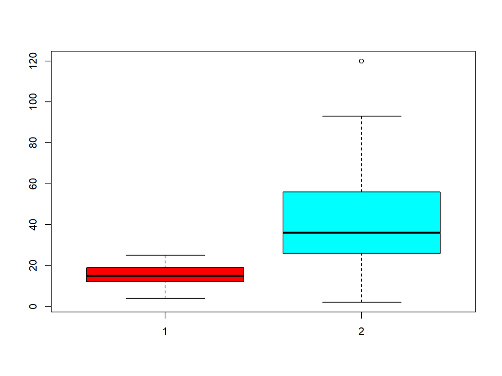

El boxplot muestra un valor atípico en la variable dist por lo cúal revisaremos usamos el metodo de deteción de outlier mediante el rango intercuartilico.

```r
cbind(quantile(cars$dist,0.75)+1.5*IQR(cars$dist),quantile(cars$dist,0.25)-1.5*IQR(cars$dist))
```

```
##     [,1] [,2]
## 75%  101  -19
```

```r
which(cars$dist>101)
```

```
## [1] 49
```

El dato 49 de la variable dist es outlier.

Se realiza comprobación de supuestos para construir un modelo de regresión.

```
##
##  Shapiro-Wilk normality test
##
## data:  cars$dist
## W = 0.95144, p-value = 0.0391
```

El data set no cumple con los supuestos sin embargo se realizara un modelo lineal en el cúal la variable respuesta es speed y la explicativa es dist.

```
##
## Call:
## lm(formula = cars$speed ~ cars$dist)
##
## Residuals:
##     Min      1Q  Median      3Q     Max
## -7.5293 -2.1550  0.3615  2.4377  6.4179
##
## Coefficients:
##             Estimate Std. Error t value Pr(>|t|)
## (Intercept)  8.28391    0.87438   9.474 1.44e-12 ***
## cars$dist    0.16557    0.01749   9.464 1.49e-12 ***
## ---
## Signif. codes:  0 '***' 0.001 '**' 0.01 '*' 0.05 '.' 0.1 ' ' 1
##
## Residual standard error: 3.156 on 48 degrees of freedom
## Multiple R-squared:  0.6511, Adjusted R-squared:  0.6438
## F-statistic: 89.57 on 1 and 48 DF,  p-value: 1.49e-12
```

Tanto el intercepto como la distancia de frenado son varibles significativas para el modelos, ademas vemos un $R^2$ ajustado de 0.64 por lo cal no es mejor ajuste.

Debido a que el modelo no cumple los supuestos y no existe un buen ajuste se procede a realizar la transformación de BoxCox

```r
library(forecast)
  cars2<- cars
transform <- function(x){
  x <- BoxCox(x, lambda = BoxCox.lambda(x))
}
cars2 <- as.data.frame(sapply(cars2, transform))
```

```
##      speed     dist
## 1 2.171059 0.783650
## 2 2.171059 3.526023
## 3 3.712078 1.780480
## 4 3.712078 5.543019
## 5 4.163544 4.661425
## 6 4.593200 3.526023
```

Veremos que ha pasado con los datos atipicos y la normalidad

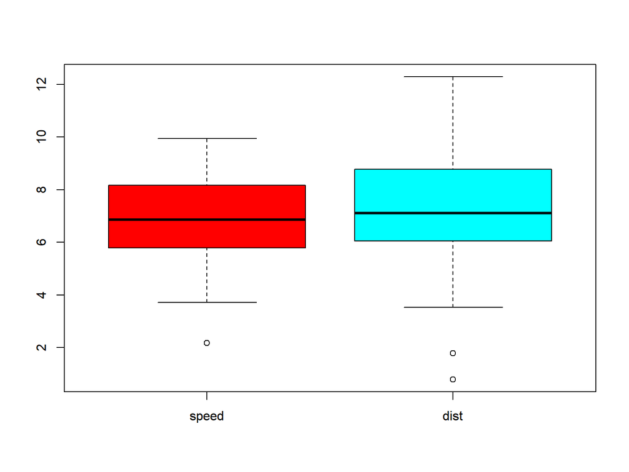

```
##
##  Shapiro-Wilk normality test
##
## data:  cars2$speed
## W = 0.9664, p-value = 0.1646
```

```
##
##  Shapiro-Wilk normality test
##
## data:  cars2$dist
## W = 0.98649, p-value = 0.8334
```

Ahora haremos el modelo resultante despues de la transformaión.

```
##
## Call:
## lm(formula = cars2$dist ~ cars2$speed)
##
## Coefficients:
## (Intercept)  cars2$speed
##    -0.09958      1.07446
```

```
##
## Call:
## lm(formula = cars2$dist ~ cars2$speed)
##
## Residuals:
##     Min      1Q  Median      3Q     Max
## -2.2914 -0.8456 -0.1705  0.7269  3.4134
##
## Coefficients:
##             Estimate Std. Error t value Pr(>|t|)
## (Intercept) -0.09958    0.68422  -0.146    0.885
## cars2$speed  1.07446    0.09629  11.158 6.21e-15 ***
## ---
## Signif. codes:  0 '***' 0.001 '**' 0.01 '*' 0.05 '.' 0.1 ' ' 1
##
## Residual standard error: 1.268 on 48 degrees of freedom
## Multiple R-squared:  0.7217, Adjusted R-squared:  0.716
## F-statistic: 124.5 on 1 and 48 DF,  p-value: 6.209e-15
```

A pesar de que el intercepto ya no es significativo el $R^2$ del modelo aumento en 0.1 puntos,esto se debe a que se corrigio el problema de la normalidad podemos ajustar un mejor modelo.

```
## [1] 0.6051103
```

# Conclusiones

- El uso de esta transformación no garantiza que los datos obtenidos se ajusten a una ley de distribución normal.
- Forzar datos a la normalidad solo se debe hacer como verificación,se recomienda pruebas de bondad de ajuste a distribuciones acordes al modelo.

# Referecias

- Box, G. E. P. and Cox, D. R. (1964) An analysis of transformations. JRSS B 26 211–246.
- Fox, J. and Weisberg, S. (2019) An R Companion to Applied Regression, Third Edition, Sage.
- Guerrero, V.M. (1993) Time-series analysis supported by power transformations. Journal of Forecasting, 12, 37–48.
- Hawkins, D. and Weisberg, S. (2017) Combining the Box-Cox Power and Generalized Log Transformations to Accomodate Nonpositive Responses In Linear and Mixed-Effects Linear Models South African Statistics Journal, 51, 317-328.
- Weisberg, S. (2014) Applied Linear Regression, Fourth Edition, Wiley Wiley, Chapter 7
- Yeo, In-Kwon and Johnson, Richard (2000) A new family of power transformations to improve normality or symmetry. Biometrika, 87, 954-959.